# scales 1.0.0

Dana Seidel

2018-08-01

We’re delighted to announce the release of [scales](https://scales.r-lib.org/) 1.0.0. This is a major release with significant changes to the popular formatter functions, and added transformations. See the [News](https://scales.r-lib.org/news/index.html) for a detailed list of changes.

Install the latest version with:

```r
install.packages("scales")
```

# New features

## Formatter changes

Thanks to the help of [@larmarange](https://github.com/larmarange), scales has now added a generic formatter function, `number_format()`, that powers the majority of the formatters in the package.

This change altered the arguments of most of the formatters: `comma_format()`, `percent_format()`, `unit_format()`, `dollar_format()`, `ordinal_format()`, and `scientific_format()`. All gained new arguments `accuracy`, `scale`, `prefix`, and `suffix`, allowing users to specify rounding accuracy, a scaling value, a prefix, and a suffix to customize output. Furthermore, all of these functions now allow user specification of the thousands separator, `big.mark`, and the decimal separator, `decimal.mark`. Users of these formatters will notice that the default thousands separator is now a space. This default was chosen as a useful compromise for an international audience (a space for thousands separator and a dot for decimal separator) and is officially endorsed by SI/ISO 31-0 standard, as well as by the International Bureau of Weights and Measures and the International Union of Pure and Applied Chemistry (IUPAC), the American Medical Association’s widely followed AMA Manual of Style, and the Metrication Board, among others ([read more here](https://www.wikiwand.com/en/Decimal_separator#/Digit_grouping)). Those interested in number formatting with no separator can simply define `big.mark = ""` to revert to the previous behaviour.

```r
number(c(12.3, 4, 12345.789, 0.0002))
```

```
#> [1] "12"     "4"      "12 346" "0"
```

```r
# these functions round by default, but you can set the accuracy
number(c(12.3, 4, 12345.789, 0.0002), big.mark = "", accuracy = .01)
```

```
#> [1] "12.30"    "4.00"     "12345.79" "0.00"
```

Three additional formatters have been added: `pvalue_format()` formats p-values, `number_bytes_format()` formats numeric vectors into byte measurements, and `time_format()` provides support for formatting POSIXt and hms objects. Finally, `ordinal_format()` has gained new rules for French and Spanish formatting.

## New transformations

Two new transformations were added to the package for this release: `psuedo_log_trans()`, and `modulus_trans()`. `pseudo_log_trans()` transforms data on a signed logarithmic scale with a smooth transition to a linear scale around 0. The `modulus_trans()` was added along with a refactored `boxcox_trans()` to provide a better option for negative numbers. Both `modulus_trans()` and `boxcox_trans()` gained an argument `offset` which now allows users to fit both type-1 and type-2 Box-Cox transformations.

## Better breaks

In a long awaited fix, `log_breaks()` now returns integer multiples of integer powers of base when finer breaks are needed on the log scale. This will change all ggplot graphics with log-transformed axes.

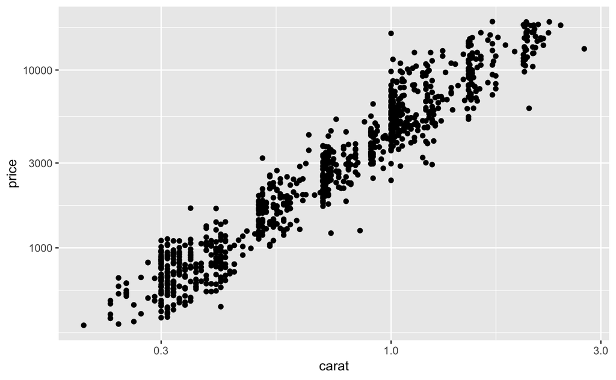

```r
dsamp <- sample_n(1000, tbl = diamonds)
ggplot(dsamp, aes(y = price, x = carat)) +
  geom_point() + scale_x_log10() + scale_y_log10()
```

# Acknowledgements

We’re grateful to the 24 people who contributed issues, code and comments: [@alexandreliborio](https://github.com/alexandreliborio), [@AndreaCirilloAC](https://github.com/AndreaCirilloAC), [@batpigandme](https://github.com/batpigandme), [@BenOnEarth](https://github.com/BenOnEarth), [@billdenney](https://github.com/billdenney), [@Bisaloo](https://github.com/Bisaloo), [@CesarSancho](https://github.com/CesarSancho), [@christianhomberg](https://github.com/christianhomberg), [@clauswilke](https://github.com/clauswilke), [@cwickham](https://github.com/cwickham), [@dpseidel](https://github.com/dpseidel), [@foo-bar-baz-qux](https://github.com/foo-bar-baz-qux), [@graciecorgi](https://github.com/graciecorgi), [@hadley](https://github.com/hadley), [@jimhester](https://github.com/jimhester), [@jnolis](https://github.com/jnolis), [@larmarange](https://github.com/larmarange), [@lepennec](https://github.com/lepennec), [@markvanderloo](https://github.com/markvanderloo), [@ptoche](https://github.com/ptoche), [@RobertMyles](https://github.com/RobertMyles), [@statist7](https://github.com/statist7), [@ThierryO](https://github.com/ThierryO), and [@zeehio](https://github.com/zeehio).